# GCN: normalize, propagate, reproduce

Three live TODOs, full inline model/trainer and full Cora experiment. PyTorch port of the MIT-licensed tkipf/gcn release; data and original source hashes are embedded. No repository import is needed. Complete the short checks before launching 100 runs.

```python
# Colab setup: record your runtime; the exact author snapshot is linked in the contract.
import sys,subprocess
if 'google.colab' in sys.modules:
    subprocess.check_call([sys.executable,'-m','pip','install','-q','numpy','scipy','torch'])
```

## Your win: explain every coefficient in a trained GCN

In [L081](https://avistian.github.io/relational/lessons/0081-mpnn-framework.html), you chose message, aggregate, update and readout functions. That interface leaves a question open: **which messages should a particular model send?** Here you will derive and implement one answer, then train it on the complete Cora citation graph. This gives our relational-learning mission a concrete baseline for learned aggregation. Cora is a static citation task; it does not establish an advantage on a temporal database.

**Route:** 25 minutes for arithmetic and the mechanism; 35 minutes for the three coding exercises. Run the separate 100-initialization experiment afterward. The full model and trainer are visible in the notebook. Exercises · [Reference card](https://avistian.github.io/relational/reference/0082-gcn.html) · [Reproduction contract](https://avistian.github.io/relational/labs/l082-reproduction.md).

THE BIG PICTURE · LESSON 082

**Build on what you know.** [Lesson 81](https://avistian.github.io/relational/lessons/0081-mpnn-framework.html) left M and U open. GCN chooses a fixed graph-dependent coefficient and a learned feature transform. The familiar residual and attention layers from Lessons 42–46 help separate topology, weights and nonlinearities.

**The next question.** [Lesson 83](https://avistian.github.io/relational/lessons/0083-graphsage.html) asks how to compute on new nodes and bounded neighborhoods. [Lesson 85](https://avistian.github.io/relational/lessons/0085-over-smoothing.html) asks what repeatedly applying graph mixing can erase. Neither question is answered by one high Cora score.

[Open the SSL → relational → graph model map](https://avistian.github.io/relational/reference/0071-0090-model-map.html) · Spend 15–20 minutes tracing this overview before the detailed mechanism and lab.

## Derive the coefficient before trusting the layer name

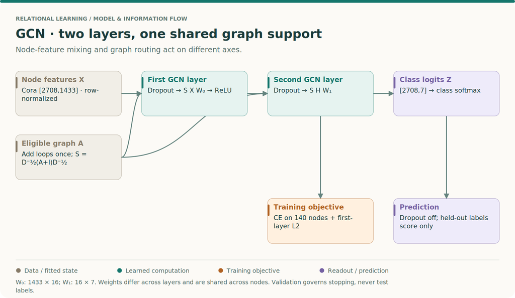

Read the arrows as data dependencies. Teal: learned computation; amber: training objective; violet: readout or prediction. This is a computation overview; exact settings and paper/release differences are specified below.

### Read from the practical layer back to its motivation

Begin with [Kipf & Welling Eq. (2), then §§2.1–2.2](https://arxiv.org/html/1609.02907v4#S2). First identify every dimension in H′=σ(SHW). Then read how the spectral approximation motivates the layer. This order lets the derivation explain a computation you can already carry out.

### Derive one receiving node's update

1. **Start with adjacency, not degrees from another graph.** For A—B—C, add one self-loop per node. The augmented degrees are 2,3,2. Computing degrees before adding loops would make both the self and neighbor coefficients wrong.
2. **Apply normalization on both ends.** The message A→B gets 1/√(2×3), B→B gets 1/3, and C→B gets 1/√(2×3). Source degree matters as well as receiver degree. This is why a uniform incoming mean is not the same operator.
3. **Multiply the example values.** With h=[2,4,8] and scalar W=1, the contributions are approximately 0.8165, 1.3333 and 3.2660. Their sum is 5.4158. The row's coefficients sum to about 1.1498, so the result need not be a convex average.
4. **Introduce feature learning separately.** With F input coordinates and D outputs, W has shape [F,D]. The same W transforms every node. S has shape [N,N] and carries graph structure. For a linear step, S(HW)=(SH)W; inserting nonlinearities or dropout between these products can break that equivalence.
5. **Compose the actual classifier.** The first layer gives [N,16], followed by ReLU. The second gives [N,7] logits for Cora. Graph propagation shares S across layers; feature weights differ. Training dropout is disabled at inference.
6. **Mask the loss, not necessarily the graph.** In this transductive experiment the full feature graph is allowed. Cross-entropy reads only training targets. Removing test nodes changes the task; retaining test labels in the objective invalidates it.

**Check: what does an isolated node do after adding its self-loop?**

Its augmented degree is one and its support row contains only a self coefficient of one. The layer applies its learned feature transform and activation without receiving any neighbor information. Without the self-loop, the behavior would require a different convention.

**Your intermediate artifact:** submit the augmented adjacency, degree vector, three coefficients and output for B. Then perturb only a held-out label and verify the training objective is unchanged. The arithmetic check and the access check establish different properties.

## 1 · A graph-specific choice of message

Let A contain undirected edges and no self-loops. Add I **before** computing degrees. Write T=A+I, dᵢ=ΣⱼTᵢⱼ and Sᵢⱼ=Tᵢⱼ/√(dᵢdⱼ). The layer is

**H′ = σ(SHW).**

Rows index nodes; columns index channels. W mixes channels with parameters shared across all nodes. S routes those mixed channels between nodes. In L081's language, the message j→i is HⱼW/√(dᵢdⱼ), aggregation is a sum over neighbors including i, and the update applies σ. Each layer has its own W; the graph support S is reused. Node classification needs one prediction per node, so there is no graph pooling.

This is the propagation rule in [Kipf & Welling, §2, Eq. 2](https://arxiv.org/html/1609.02907v4#S2). The dense implementation below exposes the algebra; the lab uses sparse matrices for the full graph.

```
T = A + np.eye(len(A))
d = T.sum(axis=1)
S = T / np.sqrt(d[:, None] * d[None, :])
H_next = np.maximum(0, S @ H @ W)
```

## 2 · Trace an unequal-degree graph

Take A—B—C and an isolated D, with scalar states [2,4,8,10] and W=1. After adding loops, degrees are [2,3,2,1]. Before looking below, calculate B's output and compare it with an ordinary mean over A, B and C.

**Pause and write your prediction before reading the explanation.**

Scroll horizontally on narrow screens to inspect the full computation.

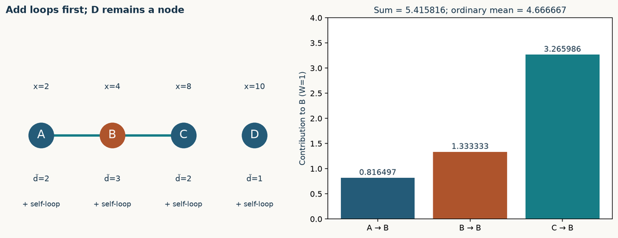

Four-node arithmetic: loops, augmented degrees and each contribution to B.

**Pause and write your prediction before reading the explanation.**

B receives 2/√6 from A, 4/3 from itself and 8/√6 from C: **5.415816**. The ordinary self-inclusive mean is 14/3=4.666667. GCN weights are symmetric, but their row sums need not be one. D retains 10 because its augmented degree is one. Self-loops preserve a route for its own features; they do not guarantee perfect identity preservation after learned channel mixing and activation.

**Intervention:** set C=20. B becomes 10.314796. A is unchanged after one layer because C has no direct edge to A. After two layers C can influence A through B. This locality statement holds for feature changes with a fixed graph; changing topology can also change normalization coefficients. In particular, adding an edge incident to B changes the A←B coefficient even if the new node is not A's neighbor.

### Which signal does normalization preserve?

“Normalized” does not mean that every constant signal stays constant. On the same A—B—C plus isolated D graph, set every input to 1, keep W=1 and omit nonlinearities. One multiplication by S gives approximately **[0.9082,1.1498,0.9082,1]**. The middle node rises even though no input exceeded 1; this would be impossible for an ordinary neighbor average.

There is a different fixed signal. Let qᵢ=√dᵢ using the **augmented** degrees, so q=[√2,√3,√2,1]. Then Sq=q. At B, each of its three terms is 1/√3, giving 3/√3=√3. In general, the factor √dⱼ cancels the source-degree denominator, leaving dᵢ/√dᵢ=√dᵢ.

| Input pattern | A after S | B after S | C after S |
| --- | --- | --- | --- |
| All ones | 0.9082 | 1.1498 | 0.9082 |
| Square-root degree | 1.4142 | 1.7321 | 1.4142 |

D stays at 1 in both cases. **Try it:** compute S twice on q and on the all-ones vector. Only q is already fixed after the first step. Then use a regular triangle, where all augmented degrees are equal: the constant signal is fixed there too. This explains why testing only equal-degree graphs can hide a mistaken row-normalization implementation. The claim concerns S alone; learned W, dropout and activations can change it. [Lesson 85](https://avistian.github.io/relational/lessons/0085-over-smoothing.html) returns to what repeated mixing preserves and erases.

### Keep the graph; now learn a channel map

A **channel** is one coordinate of a node's feature vector. The scalar example hid W's job because W=1. Keep the same four nodes and support S, but add a second coordinate: H has rows A=[2,1], B=[4,0], C=[8,2], D=[10,1]. Use the illustrative matrix W=[[1,−1],[2,1]]. These hand-picked weights are not a trained Cora model.

Predict the sign of B's second output before inspecting the diagram. Multiplication by W maps each row [x,y] to [x+2y,−x+y]. Multiplication by S then combines those transformed rows from neighboring nodes. Both H and HW have shape [4,2] here; equal shapes do not mean equal values.

Scroll horizontally on narrow screens to inspect the full computation.

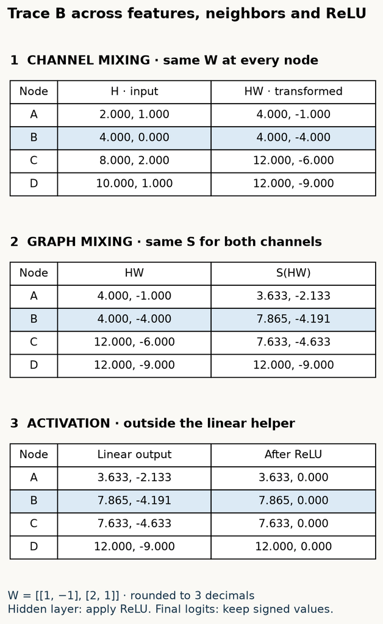

Teaching example: the same four-node graph with two input channels. Signed preactivations distinguish linear propagation from ReLU; these are illustrative weights, not Cora results.

At B, the first coordinate becomes 4/√6 + 4/3 + 12/√6 = **7.865306**; the second becomes −1/√6 − 4/3 − 6/√6 = **−4.191071**. ReLU, which replaces negative coordinates with zero, would change this row to [7.865306,0]. The linear `propagate` helper must return the signed values: the classifier applies ReLU after its first layer, but its final layer returns logits—unrestricted class scores—to cross-entropy. A checker using only positive scalar inputs cannot expose an extra ReLU.

**Transfer check:** replace W by a [2,3] matrix. Predict the output shape before coding: S[4,4] × H[4,2] × W[2,3] gives [4,3]. Node count stays fixed; the learned map changes feature width. Then choose a negative output and verify that `propagate` preserves it.

## 3 · Why this normalization has a spectral story

An eigenvector is a pattern of node values that a matrix only rescales; its eigenvalue is that scale. The normalized Laplacian is L=I−D⁻¹ᐟ²AD⁻¹ᐟ², with degrees from A before adding loops. Its eigenvectors form the columns of U. For a two-node graph with one edge, L=[[1,−1],[−1,1]]: the constant pattern [1,1] has eigenvalue 0, while the alternating pattern [1,−1] has eigenvalue 2. These are the simplest smooth and varying graph signals.

A graph Fourier filter transforms a signal into the eigenbasis U of the normalized Laplacian L, scales its spectral components, and transforms back. Explicitly computing U is expensive. The paper motivates local filters using polynomials in L; multiplying a vector by a sparse polynomial avoids that eigendecomposition. Keeping only degree one and approximating the largest eigenvalue by 2 gives a self term plus a normalized-neighbor term. Tying their coefficients yields θ(I+D⁻¹ᐟ²AD⁻¹ᐟ²).

The next step matters: replacing that operator with S is a **renormalization choice**, not an algebraic equality. The original operator can amplify a component by up to two on each application. Normalizing after adding loops controls this repeated propagation. With multiple channels, learned matrices replace the scalar coefficient. You need not calculate eigenvectors to implement the resulting local operation. Read [§2.1–2.2, Eqs. 3–9](https://arxiv.org/html/1609.02907v4#S2.SS2) and identify which steps are approximations and which are definitions.

## 4 · Model architecture: the full Cora path

Scroll horizontally on narrow screens to inspect the full computation.

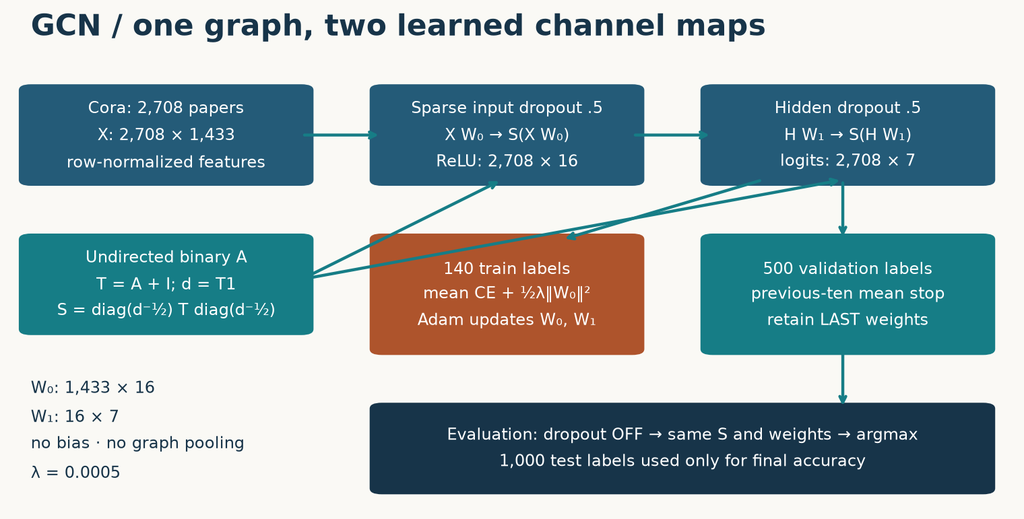

Complete Cora GCN: two layers, shared graph support, masked supervision, stopping and test inference.

Cora supplies 2,708 nodes, 1,433 input features and seven classes. The pinned release defines 140 training labels (20 per class), 500 validation nodes and 1,000 test nodes. Remaining nodes participate in propagation without entering these supervised masks. Features are row-normalized. The graph is made undirected and binary, then augmented and normalized once. Two bias-free layers use widths 1433→16→7, ReLU between layers, and 0.5 dropout on sparse input values and hidden activations during training.

```
# Evaluation path. Training additionally applies feature and hidden dropout.
H = torch.relu(propagate(S, X, W0))
logits = propagate(S, H, W1)
loss = cross_entropy(logits[train], y[train]) + 0.0005 * 0.5 * W0.square().sum()
```

Cross-entropy consumes logits; do not apply softmax first. Softmax is useful when reporting class probabilities; argmax of logits already gives the predicted class. The complete executable [port](https://avistian.github.io/relational/labs/relkit/gcn_l082.py) and notebook include initialization, sparse dropout, data loading, optimizer and stopping—not just this schematic.

## 5 · Transductive access is a task contract

Training can see the features and edges of test nodes. Their labels never enter gradients or early stopping. An unlabeled node can send a useful feature vector to a labeled neighbor; the labeled node's loss then updates the shared weights used everywhere. That is transductive semi-supervised learning, not training on the test labels. Conversely, a deployment where future rows or edges are unavailable cannot inherit this permission.

**Trace the gradient route.** Reuse A—B—C plus D, scale the original scalar features to [0.2,0.4,0.8,1], and use a one-layer teaching classifier with W=[1,−1]. Train only on B with class label 1. B's logits are approximately [0.541582,−0.541582]. Its loss depends on A's and C's features through S, so their feature gradients are nonzero. D has no route to B and receives zero feature gradient. A, C and D's *output logits* have zero direct loss gradient, because only B's output is selected. Their *labels* are not read at all. This distinction concerns dependencies; we are inspecting input gradients, not optimizing the dataset features. The notebook now checks both sides of this distinction.

**Label intervention:** change test labels while holding features, graph and masks fixed. Training gradients and the stopping epoch must stay unchanged; final test accuracy may change. **Feature intervention:** change an unlabeled neighbor's features. Training predictions may change. The distinction is what the lab's masked-loss check protects. A [separate full-training intervention](https://avistian.github.io/relational/labs/_isolation_l082_results.json) changes all test labels and checks that every validation loss and the stopping epoch remain identical; it also verifies a fresh download of all eight raw data files. See the [paper's experimental setup](https://arxiv.org/html/1609.02907v4#S5.SS2) and [released loader and preprocessing](https://github.com/tkipf/gcn/blob/39a4089fe72ad9f055ed6fdb9746abdcfebc4d81/gcn/utils.py).

## 6 · Reproduce a named result, with a declared boundary

The target is **Table 2, GCN, Cora: 81.5%**, averaged over 100 initializations. We run the full graph and released split, 200-epoch maximum schedule, and 100 initializations; no dataset cap or shortened training preset is substituted. A ±1 percentage-point mean-accuracy window is our declared educational acceptance criterion, not a tolerance asserted by the paper and not evidence of implementation identity.

**Saved author benchmark (not rerun by this exercise review):** 100 initializations; mean **81.401%**, sample SD **0.658 percentage points**, standard error **0.066 percentage points**. Difference from paper target: **-0.099 percentage points**. [Per-seed scores and complete validation traces](https://avistian.github.io/relational/labs/_paper_l082_results.json). These are measured port results, not original-framework parity.

Scroll horizontally on narrow screens to inspect the full computation.

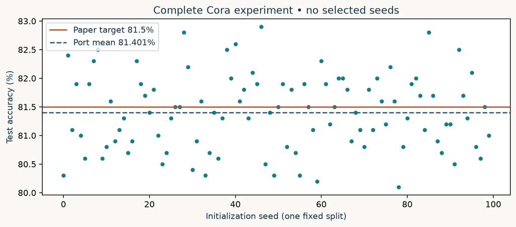

All 100 initialization scores on the same Cora split; variability is not across datasets.

The [released trainer](https://github.com/tkipf/gcn/blob/39a4089fe72ad9f055ed6fdb9746abdcfebc4d81/gcn/train.py) uses Adam at .01. Its regularizer applies to the first layer only. After zero-based epoch 10, it stops when the current regularized validation loss exceeds the preceding ten-loss mean. It evaluates the **last** weights. “Patience ten” with best-weight restoration is a different experiment. The paper's stopping prose and release rule differ; this lab follows the release.

Framework and seed differences remain: this is a PyTorch port of a TensorFlow 1 implementation; kernels, dropout RNG and Adam numerical behavior are not bitwise equivalent. The original 100 seed identities were not published; we declare seeds 0–99. The checked commit identifies the release we used, not a proven submission-era snapshot. Repeated runs share one dataset and split; sample SD describes initialization variability, not uncertainty across datasets. Original TensorFlow training, other Table 2 datasets and baseline rows are **NOT_RUN**. Live Colab and deployment are **NOT_CHECKED**.

## 7 · Inspect the representation without treating a plot as a score

Scroll horizontally on narrow screens to inspect the full computation.

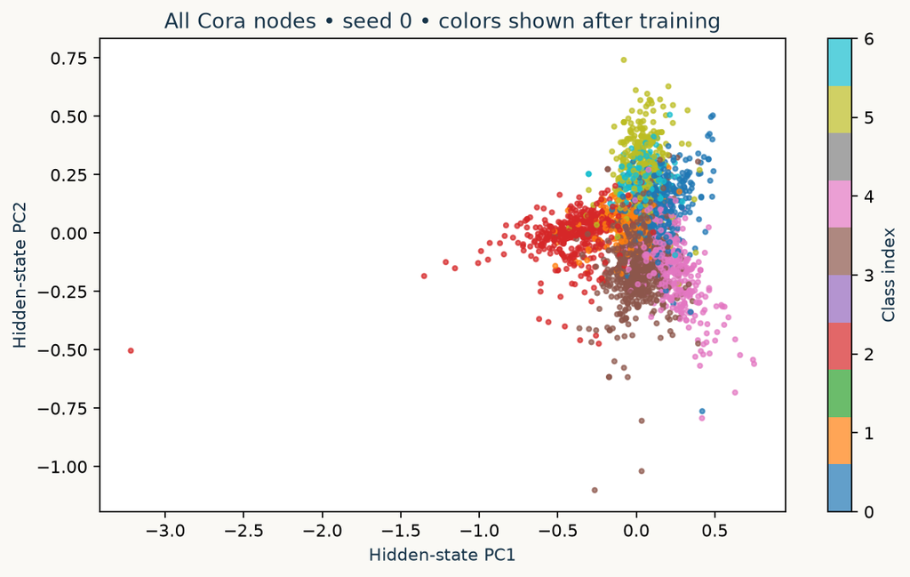

Seed-zero final hidden states projected to two principal components; descriptive visualization only.

This projection uses the final hidden states of a separate, declared seed-0 diagnostic with the same trainer. PCA is fitted to all nodes for visualization; test-label colors are added only after training. The axes explain directions of variance, not class confidence. Overlap in two dimensions neither refutes nor establishes performance in the full 16-dimensional representation. The saved per-seed test scores carry the quantitative evidence.

## 8 · TODO → CHECK → EXIT

Open the [student notebook](https://avistian.github.io/relational/labs/0082-gcn.ipynb). Each TODO is called by the real Cora training path:

1. **Normalize:** construct sparse S from loop-free binary adjacency. CHECK the exact four-node matrix, isolated D and a relabeled graph. Deliberately try row normalization and explain the failed coefficient.
2. **Propagate:** implement S(HW) for sparse or dense H. CHECK signed, two-coordinate outputs against independent dense algebra and node permutation; do not insert ReLU inside this helper because the output layer needs logits.
3. **Mask:** implement mean cross-entropy on the selected nodes plus first-layer L2. CHECK zero direct logit gradients outside the mask and invariant loss under held-out label changes. Explain why hidden states of unlabeled neighbors can still receive gradients through routing.

Run one diagnostic first, then all 100 initializations without changing the configuration in response to test scores. Submit `l082-exit.json`, the complete results JSON and your written explanation of one failed intervention. The notebook records measured values and checks the declared accuracy window; it does not claim mastery for you. Return tomorrow to reconstruct B's three coefficients and the stopping rule without notes.

**Pause and write your prediction before reading the explanation.**

Ask the agent follow-up questions or bring a failed CHECK: include your prediction, actual value and smallest example. Next, L083 asks how to aggregate when the graph grows and full-graph training becomes impractical. GraphSAGE changes the sampling and aggregation recipe; distinguish that practical shift from the false claim that GCN's weight matrices are tied to particular node IDs.

**Primary reading:** [Kipf & Welling (ICLR 2017), §§2–3 and Table 2](https://arxiv.org/html/1609.02907v4). [Pinned implementation](https://github.com/tkipf/gcn/tree/39a4089fe72ad9f055ed6fdb9746abdcfebc4d81). [Evidence and exact commands](https://avistian.github.io/relational/labs/l082-reproduction.md).

```python
from pathlib import Path
import json
ROOT=Path.cwd()
manifest={'revision': '39a4089fe72ad9f055ed6fdb9746abdcfebc4d81', 'repository': 'https://github.com/tkipf/gcn', 'files': [{'path': 'sources/l078/metrics.py', 'upstream': 'gcn/metrics.py', 'sha256': '953720296d440cfed948cd83c3162b72c4a5c759a5c1d1754254437cd0849f3f'}, {'path': 'sources/l078/utils.py', 'upstream': 'gcn/utils.py', 'sha256': '27bae983a6fdcaba352535e2a3edc46d1d9a0aabbcb7707c5212b41c27f9f8c4'}, {'path': 'sources/l078/models.py', 'upstream': 'gcn/models.py', 'sha256': 'd43548ab937264cf434e839dfd5768bd3e423579e48ae342608cafa4c8600c07'}, {'path': 'sources/l078/train.py', 'upstream': 'gcn/train.py', 'sha256': 'dab41c1c34315796ad998e1fcb4f8403719d059a970441ba358742a6bdd25136'}, {'path': 'sources/l078/LICENCE', 'upstream': 'LICENCE', 'sha256': 'f119df67ca11e39584fa0f5ee17cbfe8741b56b154d29fb21521e9ad01db57f8'}, {'path': 'sources/l078/layers.py', 'upstream': 'gcn/layers.py', 'sha256': 'c69ae03ae24aa6524eab61f2b2fec61c5938822fd225bdd4594406f1d24ec066'}, {'path': 'sources/l078/inits.py', 'upstream': 'gcn/inits.py', 'sha256': '21928770a797baf944392dee54eab83efaaa051a9d2365dee5d2f006689594a7'}, {'path': 'data/l078/ind.cora.ty', 'upstream': 'gcn/data/ind.cora.ty', 'sha256': '41f5ac76596a1699cc33f53084a2419e92961c42bb75f36fc38e616d348532ad'}, {'path': 'data/l078/ind.cora.ally', 'upstream': 'gcn/data/ind.cora.ally', 'sha256': '2b998f5cc7fedc86e7f97ca2498f47a1ffc1462c29e2d578b23bf3f62b6e7d71'}, {'path': 'data/l078/ind.cora.allx', 'upstream': 'gcn/data/ind.cora.allx', 'sha256': '9419ba2f26f5c35243db64aba110e0f35a04851609e0dc5433450676ca6b8543'}, {'path': 'data/l078/ind.cora.test.index', 'upstream': 'gcn/data/ind.cora.test.index', 'sha256': '297ce89af2b51a6a194181c7dbe1796c6a1cf9cd9349a88383b1b1e227867875'}, {'path': 'data/l078/ind.cora.x', 'upstream': 'gcn/data/ind.cora.x', 'sha256': '23cfa55d91c6f624233f5eb7b6e3f141f1bd2b2ae39608a63cf5d084bb27baab'}, {'path': 'data/l078/ind.cora.y', 'upstream': 'gcn/data/ind.cora.y', 'sha256': '94465c14eb53e04ca262198dcbb2521ee8af60fb3f3d546cd6ca24a511b0e7d1'}, {'path': 'data/l078/ind.cora.tx', 'upstream': 'gcn/data/ind.cora.tx', 'sha256': 'b9afbaa4a400df991f6f02ef677e1e44da55ffc04801fd02f9e673987829226a'}, {'path': 'data/l078/ind.cora.graph', 'upstream': 'gcn/data/ind.cora.graph', 'sha256': '58f13302f39dde8852dad6fe6d15b89b077b6d7f837626bce671ef80344b383d'}]}
manifest_path=ROOT/'_sources_l078.json'
if manifest_path.exists():
    assert json.loads(manifest_path.read_text())==manifest, 'Existing provenance differs'
else:
    manifest_path.write_text(json.dumps(manifest,indent=2))
```

## Source attribution and license

Port adapted from tkipf/gcn revision `39a4089fe72ad9f055ed6fdb9746abdcfebc4d81`.

```
The MIT License

Copyright (c) 2016 Thomas Kipf

Permission is hereby granted, free of charge, to any person obtaining a copy
of this software and associated documentation files (the "Software"), to deal
in the Software without restriction, including without limitation the rights
to use, copy, modify, merge, publish, distribute, sublicense, and/or sell
copies of the Software, and to permit persons to whom the Software is
furnished to do so, subject to the following conditions:

The above copyright notice and this permission notice shall be included in
all copies or substantial portions of the Software.

THE SOFTWARE IS PROVIDED "AS IS", WITHOUT WARRANTY OF ANY KIND, EXPRESS OR
IMPLIED, INCLUDING BUT NOT LIMITED TO THE WARRANTIES OF MERCHANTABILITY,
FITNESS FOR A PARTICULAR PURPOSE AND NONINFRINGEMENT. IN NO EVENT SHALL THE
AUTHORS OR COPYRIGHT HOLDERS BE LIABLE FOR ANY CLAIM, DAMAGES OR OTHER
LIABILITY, WHETHER IN AN ACTION OF CONTRACT, TORT OR OTHERWISE, ARISING FROM,
OUT OF OR IN CONNECTION WITH THE SOFTWARE OR THE USE OR OTHER DEALINGS IN
THE SOFTWARE.
```

```python
from pathlib import Path
```

```python
import hashlib
```

```python
import json
```

```python
import pickle
```

```python
import urllib.request
```

```python
import numpy as np
```

```python
import scipy.sparse as sp
```

```python
import torch
```

```python
from torch import nn
```

```python
import torch.nn.functional as F
```

### PROVIDED · as_sparse

Inspect the full implementation.

```python
def as_sparse(a):
    a=sp.coo_matrix(a)
    return torch.sparse_coo_tensor(np.array([a.row,a.col]),a.data.astype('float32'),a.shape).coalesce()
```

### TODO · normalized_support

Binary undirected loop-free adjacency -> sparse D^-1/2 (A+I) D^-1/2. Add exactly one self-loop per node BEFORE computing degrees; retain isolated nodes.

```python
def normalized_support(a):
    raise NotImplementedError("Implement normalized_support; see the contract and CHECK")
```

```python
a=sp.csr_matrix([[0,1,0,0],[1,0,1,0],[0,1,0,0],[0,0,0,0]],dtype=float)
s=normalized_support(a)
expected=torch.tensor([[.5,6**-.5,0,0],[6**-.5,1/3,6**-.5,0],[0,6**-.5,.5,0],[0,0,0,1]],dtype=torch.float32)
torch.testing.assert_close(s.to_dense(),expected)
assert not torch.allclose(s.to_dense().sum(1),torch.ones(4))
p=np.array([2,0,3,1]);torch.testing.assert_close(normalized_support(a[p][:,p]).to_dense(),expected[p][:,p])
print('CHECK: exact coefficients, isolated node, non-mean weights, permutation')
```

### TODO · propagate

S [N,N] times H [N,F] times W [F,C] -> [N,C]; S is sparse.

```python
def propagate(s,h,w):
    raise NotImplementedError("Implement propagate; see the contract and CHECK")
```

```python
h=torch.tensor([[2.],[4.],[8.],[10.]]);w=torch.ones(1,1)
out=propagate(s,h,w)
torch.testing.assert_close(out,expected@h)
torch.testing.assert_close(propagate(s,h.to_sparse(),w),out)
torch.testing.assert_close(propagate(normalized_support(a[p][:,p]),h[p],w),out[p])
# Keep the graph; introduce a second feature and a non-identity channel map.
h2=torch.tensor([[2.,1.],[4.,0.],[8.,2.],[10.,1.]])
w2=torch.tensor([[1.,-1.],[2.,1.]])
want=expected@torch.tensor([[4.,-1.],[4.,-4.],[12.,-6.],[12.,-9.]])
actual=propagate(s,h2,w2)
torch.testing.assert_close(actual,want)
torch.testing.assert_close(propagate(s,h2.to_sparse(),w2),want)
assert (actual[:,1]<0).all(), 'propagate must preserve negative logits'
print('CHECK: dense/sparse inputs, learned channel mixing, signed logits and equivariance')
```

### TODO · masked_objective

Mean cross-entropy on selected nodes plus release L2 on FIRST weights only.

```python
def masked_objective(logits,y,index,w0):
    raise NotImplementedError("Implement masked_objective; see the contract and CHECK")
```

```python
z=torch.tensor([[1.,0.],[0.,1.],[2.,0.]],requires_grad=True)
y=torch.tensor([0,1,1]);index=torch.tensor([0,1]);w0=torch.ones(2,2,requires_grad=True)
loss=masked_objective(z,y,index,w0);loss.backward()
assert torch.count_nonzero(z.grad[2])==0
torch.testing.assert_close(w0.grad,.0005*w0)
y2=y.clone();y2[2]=0
torch.testing.assert_close(loss,masked_objective(z,y2,index,w0))
# Masked OUTPUT gradients do not imply masked INPUT gradients.
features=torch.tensor([[.2],[.4],[.8],[1.]],requires_grad=True)
logits=propagate(s,features,torch.tensor([[1.,-1.]]))
logits.retain_grad()
labels=torch.tensor([0,1,0,1]);train=torch.tensor([1])
objective=masked_objective(logits,labels,train,torch.zeros(1,2))
objective.backward()
assert torch.count_nonzero(logits.grad[[0,2,3]])==0
assert features.grad[0].abs().item()>0 and features.grad[2].abs().item()>0
assert features.grad[3].item()==0
changed=labels.clone();changed[[0,2,3]]=1-changed[[0,2,3]]
torch.testing.assert_close(objective,masked_objective(logits,changed,train,torch.zeros(1,2)))
print('CHECK: held-out labels excluded; neighboring features receive gradients; isolated D does not')
```

### PROVIDED · load_cora

Verified pinned pickles only. Download missing files; reject changed bytes.

```python
def load_cora(root=None):
    """Verified pinned pickles only. Download missing files; reject changed bytes."""
    if root is None:
        root=Path.cwd()
        if (root/'labs').is_dir():root=root/'labs'
        if not (root/'_sources_l078.json').exists():
            root=Path(__file__).resolve().parents[1]
    root=Path(root);manifest=json.loads((root/'_sources_l078.json').read_text())
    for record in manifest['files']:
        if not record['path'].startswith('data/'):continue
        p=root/record['path'];p.parent.mkdir(parents=True,exist_ok=True)
        if not p.exists():
            url='https://raw.githubusercontent.com/tkipf/gcn/'+manifest['revision']+'/'+record['upstream']
            p.write_bytes(urllib.request.urlopen(url,timeout=60).read())
        if hashlib.sha256(p.read_bytes()).hexdigest()!=record['sha256']:
            raise ValueError('Pinned data hash mismatch: '+str(p))
    folder=root/'data/l078'
    def read(name):
        with (folder/('ind.cora.'+name)).open('rb') as f:return pickle.load(f,encoding='latin1')
    x,y,tx,ty,allx,ally,graph=[read(k) for k in ['x','y','tx','ty','allx','ally','graph']]
    reorder=np.loadtxt(folder/'ind.cora.test.index',dtype=int);ordered=np.sort(reorder)
    features=sp.vstack((allx,tx)).tolil();features[reorder]=features[ordered]
    labels=np.vstack((ally,ty));labels[reorder]=labels[ordered]
    rows=[];cols=[]
    for i,neighbors in graph.items():
        for j in neighbors:rows.extend([i,j]);cols.extend([j,i])
    a=sp.coo_matrix((np.ones(len(rows)),(rows,cols)),shape=(len(labels),len(labels))).tocsr();a.data[:]=1
    s=normalized_support(a)
    mass=np.asarray(features.sum(1)).ravel();features=sp.diags(1/np.maximum(mass,1))@features
    return as_sparse(features),s,torch.tensor(labels.argmax(1)),torch.arange(len(y)),torch.arange(len(y),len(y)+500),torch.tensor(ordered)
```

### PROVIDED · GCN

Two bias-free layers, Glorot weights, sparse feature dropout and hidden dropout.

```python
class GCN(nn.Module):
    """Two bias-free layers, Glorot weights, sparse feature dropout and hidden dropout."""
    def __init__(self, features, classes):
        super().__init__()
        self.w0=nn.Parameter(torch.empty(features,16));self.w1=nn.Parameter(torch.empty(16,classes))
        nn.init.xavier_uniform_(self.w0);nn.init.xavier_uniform_(self.w1)

    def forward(self,x,s):
        if self.training:
            v=F.dropout(x.values(),p=.5,training=True)
            x=torch.sparse_coo_tensor(x.indices(),v,x.shape).coalesce()
        h=torch.relu(propagate(s,x,self.w0))
        h=F.dropout(h,p=.5,training=self.training)
        return propagate(s,h,self.w1)
```

### PROVIDED · train_cora

Full released schedule: current validation loss vs previous-10 mean, last weights.

```python
def train_cora(data,seed):
    """Full released schedule: current validation loss vs previous-10 mean, last weights."""
    torch.manual_seed(seed)
    x,s,y,train,valid,test=data
    model=GCN(x.shape[1],int(y.max())+1)
    opt=torch.optim.Adam(model.parameters(),lr=.01,betas=(.9,.999),eps=1e-8)
    history=[]
    def loss(logits,idx):
        return masked_objective(logits,y,idx,model.w0)
    for epoch in range(200):
        model.train();opt.zero_grad();loss(model(x,s),train).backward();opt.step()
        model.eval()
        with torch.no_grad():vl=float(loss(model(x,s),valid))
        history.append(vl)
        if epoch>10 and vl>np.mean(history[-11:-1]):break
    # Test labels are consumed once, after the validation stopping decision.
    with torch.no_grad():
        logits=model(x,s);accuracy=float((logits[test].argmax(1)==y[test]).float().mean())
    return {'seed':seed,'epochs':epoch+1,'test_accuracy':accuracy,'validation_loss':history}
```

### PROVIDED · run_cora

Inspect the full implementation.

```python
def run_cora(seeds=100,root=None):
    torch.set_num_threads(1)
    data=load_cora(root);runs=[]
    for seed in range(seeds):
        r=train_cora(data,seed);runs.append(r)
        print(f"seed {seed}: {r['test_accuracy']:.4f}, {r['epochs']} epochs",flush=True)
    a=np.array([r['test_accuracy'] for r in runs])
    return {'experiment':'Kipf-Welling Table 2 Cora fixed split; PyTorch release-protocol port','paper_target':.815,'runs':runs,'mean':float(a.mean()),'sample_sd':float(a.std(ddof=1)) if seeds>1 else None,'se':float(a.std(ddof=1)/np.sqrt(seeds)) if seeds>1 else None,'torch':torch.__version__,'numpy':np.__version__,'deviations':['PyTorch rather than TensorFlow 1; RNG and Adam numerical semantics differ','Seeds 0..99 declared locally; original 100 seed identities unavailable','Release early-stop mean rule and last weights used; paper prose describes consecutive non-improvement'],'not_run':['Other Table 2 datasets and baselines','Original TensorFlow training parity']}
```

## CHECK · full graph, masks and live functions

Data bytes are verified before unpickling. No test label enters the loss or stop rule.

```python
torch.set_num_threads(1)
data=load_cora(ROOT)
x,s,y,train,valid,test=data
assert x.shape==(2708,1433)
assert [len(train),len(valid),len(test)]==[140,500,1000]
assert len(set(train.tolist()+valid.tolist()+test.tolist()))==1640
assert torch.bincount(y[train]).tolist()==[20]*7
model=GCN(1433,7).eval()
with torch.no_grad():
    oracle=s.to_dense()@torch.relu(s.to_dense()@x.to_dense()@model.w0)@model.w1
    torch.testing.assert_close(model(x,s),oracle,atol=2e-6,rtol=1e-5)
print('CHECK: full graph and dense forward oracle')
```

## One-run diagnostic

This proves that your functions participate in optimization; it does not reproduce the 100-run mean.

```python
diagnostic=train_cora(data,0)
print({k:v for k,v in diagnostic.items() if k!='validation_loss'})
```

## Full named experiment · 100 initializations

Run this cell after all checks pass. Do not tune the model on these test outcomes. Fresh training, maximum 200 epochs each; allow several minutes on CPU. The tolerance below was declared before interpreting this lesson’s run.

```python
result=run_cora(seeds=100,root=ROOT)
Path('l082-student-results.json').write_text(json.dumps(result,indent=2))
within_tolerance=abs(result['mean']-.815)<=.01
print('Mean:',result['mean'],'SD:',result['sample_sd'],'within declared ±1pp:',within_tolerance)
assert len(result['runs'])==100
```

## EXIT · attach evidence and explain

Write your own answers: why are coefficients not row means; which labels enter each phase; why does a close score not prove cross-framework identity; what changes if new edges arrive? Include a deliberately failing normalization check and its diagnosis.

```python
artifact={'lesson':82,'runs':len(result['runs']),'mean_accuracy':result['mean'],'sample_sd':result['sample_sd'],'paper_target':.815,'educational_tolerance_pp':1,'within_tolerance':within_tolerance,'source_revision':manifest['revision'],'framework':'PyTorch port','original_tensorflow_parity':'NOT_RUN','written_explanation':'ADD YOUR EXPLANATION IN A MARKDOWN CELL'}
Path('l082-exit.json').write_text(json.dumps(artifact,indent=2))
print(json.dumps(artifact,indent=2))
```